# Not all oil types are alike - Replication of figures

```r
library(NotAllOilTypesAreAlike)
```

This vignette is a step-by-step guide to replicate each figure of the paper “Not all oil types are alike”.

# Figure 2

To prepare the data for each panel, the function `merge_quality_quantity()` is employed. This custom function combines trade flow data with crude oil quality information. This function includes a parameter that allows for a variation of the Russian Urals import share. As highlighted in the paper the default is 70% of all Russian imports are of type Urals. However, 70% is probably on the conservative side, as official sources say that Russian Urals is the most important type of crude oil imported from Russia, accounting for well over 80%.

```r
df_raw <- merge_quality_quantity() %>%
  mutate(oil_type = paste(Weight, Sulfur)) %>%
  filter(!is.na(`Typical API gravity`),
         `Reporting Country` %in% get_ea_countries()) %>%
  na.omit()

df_country <- df_raw %>%
  group_by(`Country of Origin`, oil_type) %>%
  summarize(vol = sum(`Volume (1000 bbl)`),
            api = mean_api(`Typical API gravity`,
                            weight = `Volume (1000 bbl)`),
            sul = mean(`Typical sulphur content`))
df_field <- df_raw %>%
  group_by(`Type of crude oil`, `Country of Origin`, oil_type) %>%
  summarize(vol = sum(`Volume (1000 bbl)`),
             api = mean_api(`Typical API gravity`,
                             weight = `Volume (1000 bbl)`),
             sul = mean(`Typical sulphur content`))
```

```
#> You can override using the `.groups` argument.
```

```r
df_type <- df_raw %>%
  group_by(oil_type) %>%
  summarize(vol = sum(`Volume (1000 bbl)`),
             api = mean_api(`Typical API gravity`,
                             weight = `Volume (1000 bbl)`),
             sul = mean(`Typical sulphur content`))
```

We then create the panels of figure 2 using ggplot2.

```r
plot_field <- ggplot(df_field,
                      aes(x = api, y = sul, size = vol,
                           color = oil_type, shape = oil_type)) +
  geom_point(alpha = 0.75) +
  scale_size(range = c(6, 30), guide = "none") +
  theme(legend.position = "none") +
  scale_shape_manual(values = c(17, 18, 19, 15, 8)) +
  annotate("segment", x = 35, y = 2.5, xend = 32.5, yend = 2.25,
           arrow = arrow(type = "closed", length = unit(0.02, "npc"))) +
  annotate("text", x=34,y=2.55, label = "Russian Urals", color = "#011936",
           angle = 0, hjust = 0.1, size = 3, fontface = "bold")

plot_country <- ggplot(df_country,
                        aes(x = api, y = sul, size = vol,
                             color = oil_type, shape = oil_type)) +
  geom_point(alpha = 0.75) +
  scale_size(range = c(6, 30), guide = "none") +
  theme(legend.position = "none") +
  scale_shape_manual(values = c(17, 18, 19, 15, 8)) +
  annotate("segment", x = 31.5, y = 0.1, xend = 34.5, yend = 0.15,
           arrow = arrow(type = "closed", length = unit(0.02, "npc"))) +
  annotate("text", x=26,y=0.1, label = "Kazakhstan", color = "#011936",
           angle = 0, hjust = 0.1, size = 3, fontface = "bold")

plot_type <- ggplot(df_type,
                     aes(x = api, y = sul, size = vol,
                          color = oil_type, shape = oil_type)) +
  geom_point(alpha = 0.75) +
  scale_size(range = c(6, 30), guide = "none") +
  theme(legend.position = "none") +
  scale_shape_manual(values = c(17, 18, 19, 15, 8)) +
  annotate("segment", x = 36, y = 2.7, xend = 33.4, yend = 2.5,
           arrow = arrow(type = "closed", length = unit(0.02, "npc"))) +
  annotate("text", x=34,y=2.85, label = "81% of which is\nRussian Urals",
           color = "#011936", angle = 0, hjust = 0.1, size = 3,
           fontface = "bold") +
  annotate("segment", x = 45, y = 0.715, xend = 42, yend = 0.5,
           arrow = arrow(type = "closed", length = unit(0.02, "npc"))) +
  annotate("text", x=41,y=0.84, label = "17% of which is\nKazakhstan crude",
           color = "#011936", angle = 0, hjust = 0.1, size = 3,
           fontface = "bold")

size_min <- min(df_field$vol)
size_max <- max(df_type$vol)
```

Formatting is then carried out with user-defined functions:

```r
plot_field <- gx_theme(plot_field,
                        x_title = "API gravity [°]",
                        y1_title = "Sulfur content [%]",
                        legend_position = "none",
                        text_size = 12,
                        text_colour = "black") +
  scale_y_continuous(limits = c(0, 3.5)) +
  scale_x_continuous(limits = c(13, 51)) +
  scale_size(limits = c(size_min, size_max), range = c(4, 24)) +
  theme(axis.text.x = element_text(vjust = .1))
plot_country <- gx_theme(plot_country,
                          x_title = "API gravity [°]",
                          y1_title = "Sulfur content [%]",
                          legend_position = "none",
                          text_size = 12,
                          text_colour = "black") +
  scale_y_continuous(limits = c(0, 3.5)) +
  scale_x_continuous(limits = c(13, 51)) +
  scale_size(limits = c(size_min, size_max), range = c(4, 24)) +
  theme(axis.text.x = element_text(vjust = .1))
df_field$within_ela <- ifelse(df_field$oil_type == "light sweet", 0.8, 0.2)

plot_within_ela <- gx_theme(ggplot(df_field,
                                     aes(x = api, y = sul, size = vol,
                                         color = oil_type, alpha = within_ela,
                                         shape = oil_type)) +
                               geom_point() +
                               scale_size(range = c(6, 30), guide = "none") +
                               theme(legend.position = "none") +
                               scale_shape_manual(values = c(17, 18, 19, 15, 8)),
                             x_title = "API gravity [°]",
                             y1_title = "Sulfur content [%]",
                             legend_position = "none",
                             text_size = 12,
                             text_colour = "black") +
  scale_alpha(range = c(0.1, 0.75)) +
  scale_y_continuous(limits = c(0, 3.5)) +
  scale_x_continuous(limits = c(13, 51)) +
  scale_size(limits = c(size_min, size_max), range = c(4, 24)) +
  theme(axis.text.x = element_text(vjust = .1))
plot_type <- gx_theme(plot_type,
                       x_title = "API gravity [°]",
                       y1_title = "Sulfur content [%]",
                       legend_position = "none",
                       text_size = 12,
                       text_colour = "black") +
  scale_y_continuous(limits = c(0, 3.5)) +
  scale_x_continuous(limits = c(13, 51)) +
  scale_size(limits = c(size_min, size_max), range = c(4, 24)) +
  theme(axis.text.x = element_text(vjust = .1))
# create combined legend
p <- ggplot(df_country,
               aes(x = api, y = sul, color = oil_type, shape = oil_type)) +
    geom_point(alpha = 0.75) +
    scale_shape_manual(values = c(17, 18, 19, 15, 8)) +
    scale_color_manual(values = gx_colors()) +
    theme(legend.background = element_blank(),
          legend.position   = "bottom",
          legend.title      = element_blank(),
          legend.key        = element_blank(),
          legend.text       = element_text(size = 12))+
    guides(shape = guide_legend(override.aes = list(size = 5)))

# Extract the legend. Returns a gtable
leg <- ggpubr::get_legend(p)
```

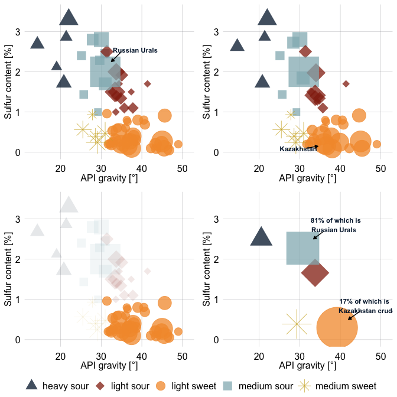

```r
  # create and print plot
  ggpubr::ggarrange(plot_field,
                    plot_country,
                    plot_within_ela,
                    plot_type,
                    common.legend = T, legend="bottom", legend.grob = leg)
```

# Figure 3

In this figure we show the distribution of Euro Area imports for the two most common crude oil types. We do this for the whole sample period to avoid year specific variation. Dottedbars refer to medium-sour and striped bars refer to light-sweet crude oil imports. Russian imports of the two types are highlighted in red and blue, respectively.

Data preparation is straightforward and involves similar steps than in figure 2.

```r
df_ea <- merge_quality_quantity() %>%
  filter(`Reporting Country` %in% get_ea_countries())

df_ea <- df_ea %>%
  mutate(`Reporting Country` = "Euro Area",
         date = as.numeric(substr(date, 1, 4))) %>%
  group_by(`Country of Origin`, `Type of crude oil`, `Reporting Country`,
           `date`, `Weight`, `Sulfur`) %>%
  summarize(`Volume (1000 bbl)` = sum(`Volume (1000 bbl)`, na.rm = T),
            `Total Value ($ 1000)` = sum(`Total Value ($ 1000)`, na.rm = T)) %>%
  ungroup() %>%
  mutate(`CIF price (2) ($/bbl)` = `Total Value ($ 1000)` / `Volume (1000 bbl)`,
          date = as.Date(paste0(date, "-12-31"))) %>%
  filter(`Total Value ($ 1000)` > 0,
          `CIF price (2) ($/bbl)` > 0,
          `Volume (1000 bbl)` > 0)
```

```
#> 'Reporting Country', 'date', 'Weight'. You can override using the `.groups`
#> argument.
```

```r
df <- df_ea %>%
  mutate(oil_type = paste(Weight, Sulfur)) %>%
  rename("country" = `Country of Origin`) %>%
  group_by(country, oil_type) %>%
  summarize(volume = sum(`Volume (1000 bbl)`)) %>%
  filter(volume > 5000) %>%
  filter(oil_type %in% c("light sweet", "medium sour")) %>%
  pivot_wider(names_from = oil_type, values_from = volume) %>%
  pivot_longer(-country) %>%
  mutate(value = ifelse(is.na(value), 0, value)) %>%
  mutate(value = value / 1000,
         country = ifelse(country == "Russian Federation", "Russia",
                          ifelse(country == "United Kingdom", "UK",
                                 ifelse(country == "United States", "USA",
                                        country))))
```

Than we create the plot and use again our custom functions for formatting:

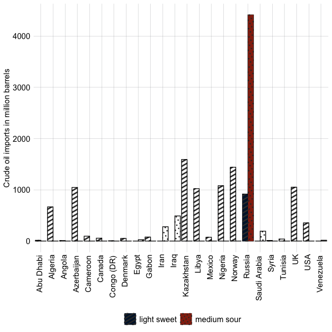

```r
plot <- ggplot(df, aes(x = country, y = value)) +
  geom_col_pattern(aes(pattern = name),
                   position        = "dodge",
                   fill            = 'white',
                   colour          = 'black',
                   pattern_spacing = 0.015) +
  geom_col_pattern(data            = filter(df, country == "Russia"),
                   mapping         = aes(fill = name, pattern = name),
                   position        = "dodge",
                   pattern_spacing = 0.015)

gx_theme(plot,
         text_size   = 12,
         text_colour = "black",
         y1_title    = "Crude oil imports in million barrels") +
  theme(axis.text.x = element_text(angle = 90, hjust = 1.05, vjust = 0.25))
```

# Figure 4

In this figure we show European crude oil imports from the United States and Russia before and after the start of the EU crude oil embargo. Panel a) Time series of imported volumes from Russia and the U.S. into the EU. Panel b) Chemical composition of crude oils imported from Russia [blue squares] in the year before the sanctions and chemical composition of U.S. imports [red bubbles] in the first year of the oil embargo. The size of the symbols refers to the volume of crude oil imports.

For this analysis we need a different dataset. We use data provide by Eurostat. At the time of writing this data contained crude oil imports into the European Union from January 2020 to October 2023 on a monthly basis. As this dataset is quite large and thus not suitable for keeping it in the package, I converted the .csv-file to .RDS which is much more memory efficient. It is still the raw data but now can be easily accessed via the package.

The data preparation is again straightforward. The only thing which is done in the following code block is reshaping the data and renaming the variables such that the code is easy to read.

```r
df <- prepare_eurostat()
```

To make it easier to follow we will separate the two panels and create one plot for each panel.

## Panel a

We apply a country filtering as we are only interested in imports from Russia and the United States. Than we aggregate across different oil types to obtain the total volume imported from each of the two countries.

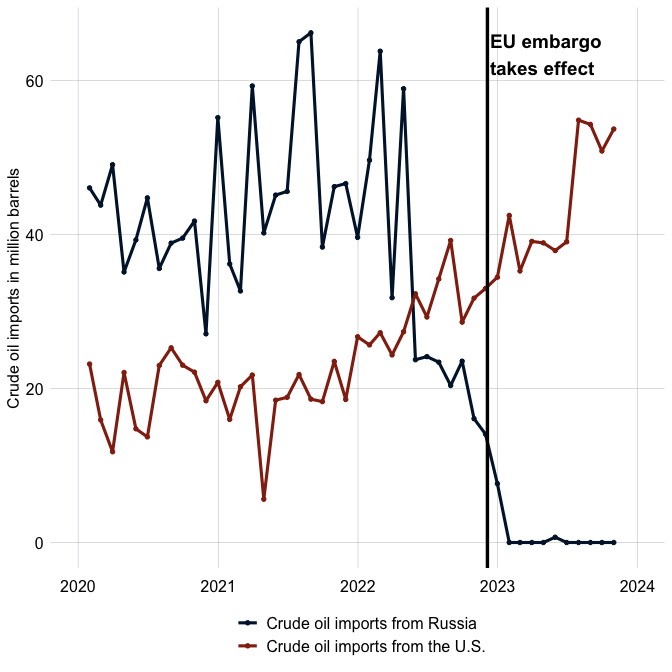

```r
df_plot <- df %>%
  filter(repCountryIso == "EU", sourceCountryIso %in% c("RU", "US")) %>%
  mutate(sourceCountryIso = ifelse(sourceCountryIso == "RU",
                                   "Crude oil imports from Russia",
                                   "Crude oil imports from the U.S.")) %>%
  group_by(month, sourceCountryIso) %>%
  summarize(volume = sum(volume),
            value = sum(value)) %>%
  mutate(avgPriceBBl = value / volume)
# continue missing RU imports with zeros (as they are true zeros)
df_plot_vol <- df_plot %>%
  select(month, sourceCountryIso, volume) %>%
  pivot_wider(names_from = month, values_from = volume)

df_plot_vol[is.na(df_plot_vol)] <- 0

df_plot_vol <- df_plot_vol %>%
  pivot_longer(-sourceCountryIso, names_to = "month", values_to = "volume") %>%
  mutate(month = as.Date(month),
         volume = volume/1000)

plot_vol <- ggplot(df_plot_vol, aes(x = month, y = volume, color = sourceCountryIso)) +
  geom_point(size = 1.2) +
  geom_line(size = 1.1) +
  geom_vline(xintercept = as.Date("2022-12-05"), color = "black", size = 1.2) +
  annotate("text", x=as.Date("2022-12-05"),y=63.5, label = "EU embargo\ntakes effect", color = "black",
           hjust = -0.025, size = 5, fontface = "bold")
gx_theme(plot_vol,
         y1_title = "Crude oil imports in million barrels",
         text_size = 12,
         legend_rows = 2,
         text_colour = "black") +
  scale_x_date(limit = c(as.Date("2020-01-01"), as.Date("2023-12-30")))
```

## Panel b

In this panel we compare the quality of crude oil imports from Russia and the United States. We focus on the year before and after the embargo comes into forces. Here we should not that the crude oil embargo was implemented on December 5th, 2022. In the quality comparison we use November 2022 as the start of the sanctions which does not influence the results. It is just that at the time of writing, the last observation available was October 2023. When we use November, we can use 12 months for both periods (Russian imports before the sanctions and U.S. imports after the sanctions).

The only thing we need to take care of is the aggregation of oil quality. Here we apply our custom function `mean_api()` as we can not simply take the average of API gravity. We first need to convert it to specific gravity before we can take means and convert back.

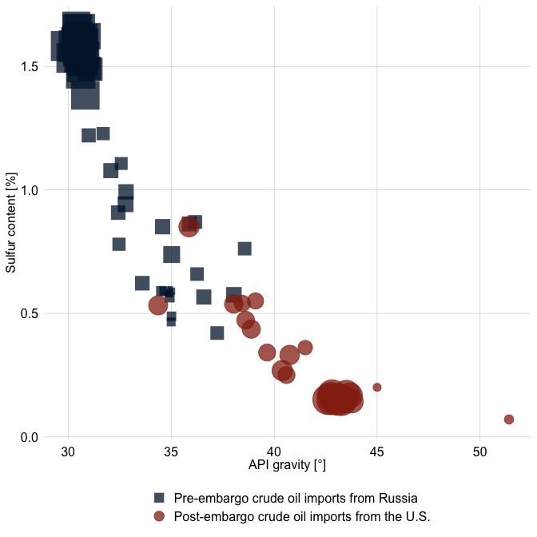

```r
df_oil_quality_ru <- df %>%
  filter(repCountryIso == "EU", sourceCountryIso %in% c("RU"),
         month <= as.Date("2022-10-31"),
         month > as.Date("2021-10-31")) %>%
  mutate(volShare = volume/sum(volume),
         meanApi = mean_api(api, volShare),
         meanSul = sum(sul*volShare)) %>%
  select(meanApi, meanSul) %>%
  unique()

df_oil_quality_us <- df %>%
  filter(repCountryIso == "EU", sourceCountryIso %in% c("US"),
         month > as.Date("2022-10-31")) %>%
  mutate(volShare = volume/sum(volume),
         meanApi = mean_api(api, volShare),
         meanSul = sum(sul*volShare)) %>%
  select(meanApi, meanSul) %>%
  unique()

df_plot_qual <- df %>%
  filter(repCountryIso == "EU", sourceCountryIso %in% c("RU", "US"),
         ((sourceCountryIso == "RU" & month <= as.Date("2022-10-31")) |
            (sourceCountryIso == "US" & month > as.Date("2022-10-31")))) %>%
  mutate(sulType = ifelse(sul < 1, "sweet", "sour"),
         apiType = ifelse(api < 22.3, "heavy", ifelse(api > 31.1, "light", "medium")),
         oilType = paste(apiType, sulType))

plot_quality_us_ru <- df_plot_qual %>%
  ggplot(aes(x = api, y = sul,
             size  = volume,
             color = sourceCountryIso,
             shape = sourceCountryIso)) +
  geom_point(alpha = 0.75 ) +
  scale_size(range = c(2, 14), guide = "none" ) +
  scale_shape_manual(values = c(15, 19))

gx_theme(plot_quality_us_ru,
          x_title     = "API gravity [°]",
          y1_title    = "Sulfur content [%]",
          legend_rows = 2,
          text_size   = 12,
          text_colour = "black") +
  theme(axis.text.x   = element_text(vjust = .1)) +
  scale_color_manual(values = c(gx_colors()[1:2]),
    labels = c("RU" = "Pre-embargo crude oil imports from Russia",
               "US" = "Post-embargo crude oil imports from the U.S.")) +
  scale_shape_manual(
    values = c(15,19),
    labels = c("RU" = "Pre-embargo crude oil imports from Russia",
               "US" = "Post-embargo crude oil imports from the U.S.")) +
  guides(color = guide_legend(nrow = 2),
         shape = guide_legend(nrow = 2, override.aes = list(size = 4)))
```